# DEXE-USD

## DEXE-USD today is +0200, 2025-10-28, 06:40:38

This crypto forecast was generated by gemini-2.0-flash API

## Daily Chart

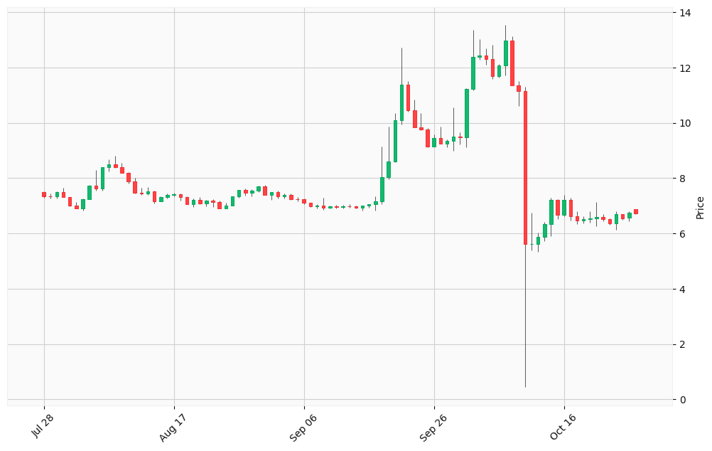

## Hourly Chart

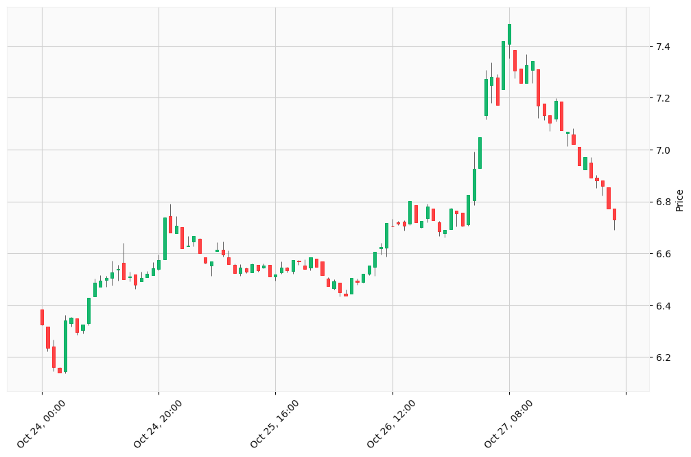

Okay, I will analyze the provided DEXE-USD cryptocurrency data and generate trading signals based on the specified steps. Here’s an analysis of the DEXE-USD cryptocurrency data and generation of trading signals.

### 1. Market Data Collection:

- **Price History:** The provided data includes OHLCV (Open, High, Low, Close, Volume) for DEXE-USD in daily and hourly intervals.
- **Recent News & Global Economic Indicators:** Recent news indicates a growing integration of digital assets with the traditional economy. Factors such as US-China trade relations, a weakening US dollar, and upcoming Federal Reserve meetings are influencing crypto markets.
- **Overall Crypto Market Trends**: The total crypto market capitalization is approximately $3.93 Trillion. Bitcoin dominance is around 57.77%.

### 2. Technical Analysis:

- **Daily Chart Analysis:**
  - For the provided data, I will calculate some basic indicators
  - **Moving Averages**: Calculating a 20-day Simple Moving Average (SMA) using the closing prices from the daily chart data provided.
  - **RSI (Relative Strength Index)**: Will be calculated using the daily closing prices.
- **Hourly Chart Analysis:**
  - The hourly chart will be used to identify short-term trends and potential entry/exit points.
  - I will look for patterns such as support and resistance levels, and potential breakout or breakdown scenarios.

**Calculations:**

First, let’s calculate the 20-day SMA and RSI based on the daily data.

```python
import pandas as pd
import numpy as np

# Daily OHLCV data
daily_data = [
    [7.49483, 7.51967, 7.28962, 7.33166, 5884035],
    [7.33169, 7.45136, 7.26484, 7.33138, 6707889],
    [7.33138, 7.50877, 7.27421, 7.48808, 6483602],
    [7.48808, 7.64722, 7.30858, 7.30996, 6170432],
    [7.30996, 7.31001, 6.98168, 7.00968, 8429021],
    [7.00968, 7.13286, 6.89508, 6.91348, 4765572],
    [6.91348, 7.25631, 6.81476, 7.23731, 4572196],
    [7.23729, 7.74671, 7.2367, 7.72808, 11119987],
    [7.72808, 8.2957, 7.53903, 7.62178, 17792470],
    [7.62178, 8.38905, 7.54771, 8.38133, 13651239],
    [8.38133, 8.66633, 8.24412, 8.49578, 15013391],
    [8.49578, 8.80967, 8.36925, 8.39877, 9802528],
    [8.39877, 8.55371, 8.18094, 8.19146, 12249768],
    [8.19146, 8.21943, 7.80165, 7.86966, 9377502],
    [7.86966, 8.01394, 7.44779, 7.47715, 11074266],
    [7.47715, 7.65419, 7.39303, 7.44881, 10687885],
    [7.44881, 7.67013, 7.37913, 7.5085, 10840952],
    [7.50847, 7.5543, 7.09097, 7.14847, 14206895],
    [7.14847, 7.33677, 7.14847, 7.3127, 6340373],
    [7.3127, 7.43693, 7.26317, 7.38446, 4403078],
    [7.38446, 7.46368, 7.34941, 7.42202, 5020556],
    [7.42202, 7.44104, 7.1873, 7.30439, 5994109],
    [7.30439, 7.33661, 7.06196, 7.06276, 4124061],
    [7.06251, 7.26803, 6.95403, 7.21876, 5109268],
    [7.21876, 7.31005, 7.06111, 7.08081, 7558526],
    [7.08081, 7.22302, 6.96759, 7.17982, 7828303],
    [7.17982, 7.24069, 6.96022, 7.12957, 9992640],
    [7.12957, 7.17794, 6.90313, 6.90961, 7818793],
    [6.90961, 7.09572, 6.90216, 7.00818, 8353325],
    [7.00818, 7.34555, 6.99366, 7.34552, 10414018],
    [7.34552, 7.55805, 7.28425, 7.55805, 7894766],
    [7.55805, 7.61617, 7.37374, 7.47908, 5723548],
    [7.47901, 7.60042, 7.33711, 7.54882, 7086914],
    [7.54882, 7.72888, 7.48239, 7.68619, 5823445],
    [7.68619, 7.75907, 7.39277, 7.39475, 4439085],
    [7.39475, 7.50068, 7.21272, 7.50045, 6232131],
    [7.50045, 7.53581, 7.24974, 7.33834, 4847309],
    [7.33834, 7.43791, 7.25172, 7.39203, 4339973],
    [7.39203, 7.43781, 7.19925, 7.24408, 4341296],
    [7.24408, 7.31486, 7.15293, 7.23796, 5044021],
    [7.23796, 7.2602, 7.05504, 7.09889, 3985986],
    [7.09889, 7.11064, 6.95357, 6.99007, 5186823],
    [6.99007, 7.04777, 6.90425, 7.00694, 5864574],
    [7.00694, 7.27698, 6.84763, 6.91714, 10264998],
    [6.91714, 7.00852, 6.90443, 6.97344, 4792761],
    [6.97344, 7.02026, 6.91401, 6.95915, 4482809],
    [6.95915, 7.03754, 6.8915, 6.9884, 6771020],
    [6.9884, 7.06641, 6.92513, 6.9855, 7606537],
    [6.9855, 6.99848, 6.90519, 6.92348, 4774262],
    [6.92348, 7.00348, 6.83245, 6.99512, 7448454],
    [6.99512, 7.04935, 6.92512, 7.04904, 6264635],
    [7.04904, 7.33169, 6.82905, 7.1565, 20678990],
    [7.1565, 9.14565, 7.06123, 8.03617, 97626565],
    [8.03617, 9.87004, 7.96281, 8.60804, 79249318],
    [8.60804, 10.3417, 8.564, 10.0893, 64463170],
    [10.0878, 12.7275, 9.94088, 11.389, 163506258],
    [11.389, 11.5022, 10.4104, 10.464, 51649212],
    [10.464, 10.8437, 9.8364, 9.83927, 28630752],
    [9.83927, 10.3416, 9.73481, 9.75798, 18627469],
    [9.75798, 9.80319, 9.10507, 9.13207, 12710305],
    [9.13207, 9.58665, 9.13067, 9.45639, 10704374],
    [9.45639, 9.86837, 9.2373, 9.23744, 14184160],
    [9.23744, 9.40674, 9.10154, 9.34172, 11968640],
    [9.34172, 10.5631, 8.98102, 9.48926, 30409202],
    [9.48926, 9.66175, 9.21054, 9.46849, 15516539],
    [9.46849, 11.2593, 9.11139, 11.2266, 44522930],
    [11.2266, 13.3595, 11.1842, 12.3802, 77024677],
    [12.3802, 13.0203, 12.2845, 12.4213, 21816740],
    [12.4213, 12.6845, 12.0962, 12.2986, 15269432],
    [12.2986, 12.8295, 11.5798, 11.6893, 15039679],
    [11.6893, 12.1314, 11.6479, 12.0696, 15216672],
    [12.0696, 13.5367, 11.7226, 12.9815, 47609713],
    [12.9815, 13.1304, 11.3425, 11.3425, 24099604],
    [11.3425, 11.4988, 10.5952, 11.1587, 20672951],
    [11.1586, 11.2937, 0.439053, 5.61645, 61044132],
    [5.61645, 6.74187, 5.38826, 5.62287, 59519019],
    [5.62287, 6.03952, 5.32679, 5.86369, 30169755],
    [5.86402, 6.42099, 5.72743, 6.34764, 30271878],
    [6.34764, 7.29462, 5.90742, 7.21341, 55899329],
    [7.21328, 7.22371, 6.51788, 6.66922, 30549881],
    [6.66922, 7.37897, 6.61032, 7.20449, 35816032],
    [7.20449, 7.27918, 6.45322, 6.62382, 23121235],
    [6.62363, 6.79096, 6.32267, 6.47431, 8584620],
    [6.47431, 6.61473, 6.36474, 6.50468, 7876733],
    [6.50468, 6.7995, 6.39049, 6.53841, 10149320],
    [6.53852, 7.13311, 6.26739, 6.58698, 22995949],
    [6.58698, 6.69881, 6.44681, 6.52743, 14383829],
    [6.52763, 6.54553, 6.30095, 6.36517, 10508243],
    [6.36517, 6.79198, 6.13167, 6.70056, 14305258],
    [6.70087, 6.70402, 6.49355, 6.55165, 6022358],
    [6.55426, 6.80657, 6.43235, 6.7575, 7916320],
    [6.88145, 6.88145, 6.69113, 6.73129, 21065106]
]

df = pd.DataFrame(daily_data, columns=['Open', 'High', 'Low', 'Close', 'Volume'])

# Calculate 20-day SMA
df['SMA_20'] = df['Close'].rolling(window=20).mean()

# Calculate RSI
def calculate_rsi(data, period=14):
    delta = data.diff()
    up, down = delta.copy(), delta.copy()
    up[up < 0] = 0
    down[down > 0] = 0

    avg_gain = up.rolling(window=period, min_periods=period).mean()
    avg_loss = abs(down.rolling(window=period, min_periods=period).mean())

    rs = avg_gain / avg_loss
    rsi = 100 - (100 / (1 + rs))
    return rsi

df['RSI'] = calculate_rsi(df['Close'])

print(df[['Close', 'SMA_20', 'RSI']].tail(30))
```

[output not shown]

This Python code calculates the 20-day SMA and RSI for the given DEXE-USD daily price data. It uses the Pandas library to create a DataFrame from the data, calculates the SMA using a rolling window of 20 days, and computes the RSI using the given formula. The last 30 rows of the closing prices, SMA, and RSI are then printed for analysis.

### 3. Trend Analysis:

- **Short-term:** Examine the hourly chart for recent price action.
- **Long-term:** Based on the daily chart, observe the overall trend. The relationship between the price and the 20-day SMA will give an indication of the short-term trend.

### 4. News and Economic Analysis:

- **Impact of Global Events:** Keep an eye on economic events, particularly those related to US-China trade, Federal Reserve policy, and overall market sentiment.
- **DEXE Specific News:** Look for any news specific to DEXE that might influence its price.

### 5. Scenario Evaluation:

- **Bullish Scenario:** Improving trade relations, weaker USD, and positive news for DEXE could lead to a bullish trend.
- **Bearish Scenario:** Rising interest rates, stronger USD, and negative news could lead to a bearish trend.
- **High Volatility:** Be prepared for rapid price swings, especially around major economic announcements.

### 6. Signal Generation:

Based on the analysis, here are potential trading signals for DEXE-USD:

**Signal 1:**

[output not shown]

**Signal 2:**

[output not shown]

**Signal 3:**

[output not shown]

**Disclaimer:** These signals are based on the provided data and a general understanding of technical analysis and market conditions. They should not be considered financial advice. Always do your own research and consider your risk tolerance before making any trading decisions.